# R Notebook

## what’s different

(simple linear regression) y = mx + c

–

(multiple linear regression) y = m1x1 + m2x2 + m3x3 + c

- rather than explain the variation of y with one predictor (x), we’re going to allow for multile predictors (X).

## The Plan

- understand our business question
- build a simple linear model
- add in another predictor
  - categorical predictor (the parallel slopes model)
- add in another predictor
  - continuous predictor
- we’ll also look at “interactions”

### 1. The Data

```r
library(mosaicData)
```

[output not shown]

[output not shown]

[output cut: 80 more lines]

Volume of Users of a Rail Trail

We’re going to build a model for ‘volume’. Can we explain the variation in ‘volume’ using other predictors?

Our candidates: - temperature (Fahrenheit) - season - cloudcover (0 to 10) - precipitation (inches) - weekday

```r
RailTrail
```

| hightemp | lowtemp | avgtemp | spring | summer | fall | cloudcover | precip | volume | weekday | dayType |
| --- | --- | --- | --- | --- | --- | --- | --- | --- | --- | --- |
| 83 | 50 | 66.5 | 0 | 1 | 0 | 7.6 | 0.00 | 501 | TRUE | weekday |
| 73 | 49 | 61.0 | 0 | 1 | 0 | 6.3 | 0.29 | 419 | TRUE | weekday |
| 74 | 52 | 63.0 | 1 | 0 | 0 | 7.5 | 0.32 | 397 | TRUE | weekday |
| 95 | 61 | 78.0 | 0 | 1 | 0 | 2.6 | 0.00 | 385 | FALSE | weekend |
| 44 | 52 | 48.0 | 1 | 0 | 0 | 10.0 | 0.14 | 200 | TRUE | weekday |
| 69 | 54 | 61.5 | 1 | 0 | 0 | 6.6 | 0.02 | 375 | TRUE | weekday |
| 66 | 39 | 52.5 | 1 | 0 | 0 | 2.4 | 0.00 | 417 | TRUE | weekday |
| 66 | 38 | 52.0 | 1 | 0 | 0 | 0.0 | 0.00 | 629 | FALSE | weekend |
| 80 | 55 | 67.5 | 0 | 1 | 0 | 3.8 | 0.00 | 533 | FALSE | weekend |
| 79 | 45 | 62.0 | 0 | 1 | 0 | 4.1 | 0.00 | 547 | TRUE | weekday |

[output cut: 80 more lines]

```r
NA
```

A couple of slight issues with the data( in it’s raw form):

- spring to fall are numbers rather than logical TRUE/FALSE
- some collinear predictors (we want our predictors to be independent)
  - temps
  - weekday / day_type
  - season

### Variable Engineering

- drop collinear columns
- convert column types
- clean up the column names

```r
railtrail_trim <- RailTrail %>%
  clean_names() %>%
  mutate(across(spring:fall, as.logical)) %>%
  select(-c(lowtemp, hightemp, fall, day_type))

railtrail_trim
```

| avgtemp | spring | summer | cloudcover | precip | volume | weekday |
| --- | --- | --- | --- | --- | --- | --- |
| 66.5 | FALSE | TRUE | 7.6 | 0.00 | 501 | TRUE |
| 61.0 | FALSE | TRUE | 6.3 | 0.29 | 419 | TRUE |
| 63.0 | TRUE | FALSE | 7.5 | 0.32 | 397 | TRUE |
| 78.0 | FALSE | TRUE | 2.6 | 0.00 | 385 | FALSE |
| 48.0 | TRUE | FALSE | 10.0 | 0.14 | 200 | TRUE |
| 61.5 | TRUE | FALSE | 6.6 | 0.02 | 375 | TRUE |
| 52.5 | TRUE | FALSE | 2.4 | 0.00 | 417 | TRUE |
| 52.0 | TRUE | FALSE | 0.0 | 0.00 | 629 | FALSE |
| 67.5 | FALSE | TRUE | 3.8 | 0.00 | 533 | FALSE |
| 62.0 | FALSE | TRUE | 4.1 | 0.00 | 547 | TRUE |

[output cut: 80 more lines]

### Detect Perfect Collinearity (column aliases)

```r
alias(volume ~ ., RailTrail)
```

```
Model :
volume ~ hightemp + lowtemp + avgtemp + spring + summer + fall +
    cloudcover + precip + weekday + dayType

Complete :
               (Intercept) hightemp lowtemp spring summer cloudcover precip
avgtemp          0         1/2      1/2       0      0      0          0
fall             1           0        0      -1     -1      0          0
dayTypeweekend   1           0        0       0      0      0          0
               weekdayTRUE
avgtemp          0
fall             0
dayTypeweekend  -1
```

Check we’ve removed this collinearity

```r
alias(volume ~ ., railtrail_trim)
```

```
Model :
volume ~ avgtemp + spring + summer + cloudcover + precip + weekday
```

Note: alias will only detect perfect matches

### Simple Linear Regression

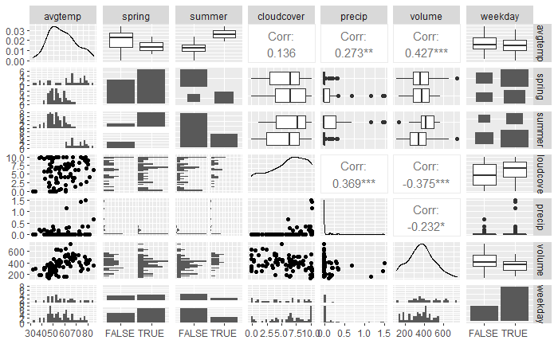

```r
library(GGally)

ggpairs(railtrail_trim)
```

Pairs Plot

Plots every variable against one another

1. correlations (high)
2. distributions of each - boxplots (boxes to be different for different categorical levels)
3. scatter plots )any discernible pattern)

Avg temperature has the highest correlation - let’s start with that.

y = intercept + m_avg_temp * avg_temp

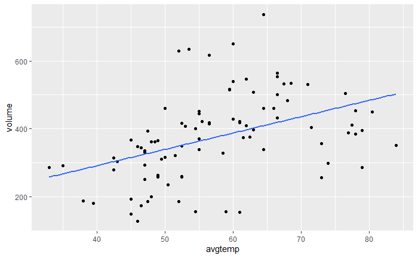

There does appear to be a linear relationship between volume and average temperature. (As temperature increases so does the volume of users on the rail trail)

### Goodness of fit metrics

- $r^2$: coefficent of determination (1 = perfect, 0 = none)
- standard error in the residuals - how far are the residuals from the line / how far on average do the fitted values differ from the measured values?

```r
summary(model)
```

```
Call:
lm(formula = volume ~ avgtemp, data = railtrail_trim)

Residuals:
    Min      1Q  Median      3Q     Max
-237.53  -80.00    8.49   55.14  326.67

Coefficients:
            Estimate Std. Error t value Pr(>|t|)
(Intercept)   99.602     63.474   1.569     0.12
avgtemp        4.802      1.084   4.428 2.72e-05 ***
---
Signif. codes:  0 ‘***’ 0.001 ‘**’ 0.01 ‘*’ 0.05 ‘.’ 0.1 ‘ ’ 1

Residual standard error: 115.9 on 88 degrees of freedom
Multiple R-squared:  0.1822,    Adjusted R-squared:  0.1729
F-statistic: 19.61 on 1 and 88 DF,  p-value: 2.723e-05
```

# Diagnostic Plots!

```r
autoplot(model)
```

[output not shown]

[output not shown]

How do we improve our model?

Add predictors

BEcause David said it might work…..

throw in weekday

### Adding a categorical predictor

Task - 2 mins Try plotting an appropriate visualisation to determine whether user volume is associated with the weekday predictor.

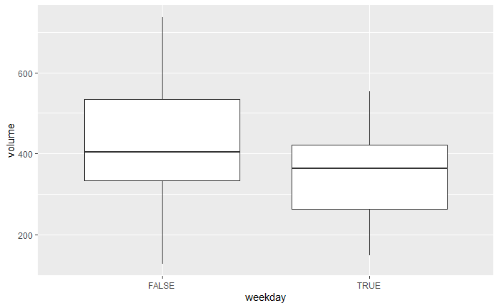

```r
railtrail_trim %>%
  ggplot(aes(x = weekday, y = volume)) +
  geom_boxplot()
```

| cor |
| --- |
| -0.2932675 |

correlation coefficient (r) = -0.3

Some evidence that volume and weekday are related. (There is a dependency)

y = intercept + (b_avg_temp * avg_temp) + (b_weekday * weekday)

```r
#patsy notation
# formula <- volume ~ avgtemp + weekday
model_temp_wday <- lm(volume ~ avgtemp + weekday,
                      railtrail_trim)
```

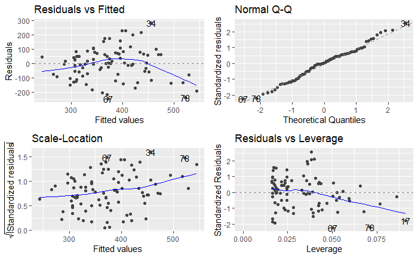

```r
autoplot(model_temp_wday)
```

```r
summary(model_temp_wday)
```

```
Call:
lm(formula = volume ~ avgtemp + weekday, data = railtrail_trim)

Residuals:
    Min      1Q  Median      3Q     Max
-242.92  -75.72    3.15   66.90  280.06

Coefficients:
            Estimate Std. Error t value Pr(>|t|)
(Intercept)  163.022     65.428   2.492  0.01461 *
avgtemp        4.541      1.050   4.323 4.08e-05 ***
weekdayTRUE  -70.320     25.566  -2.751  0.00724 **
---
Signif. codes:  0 ‘***’ 0.001 ‘**’ 0.01 ‘*’ 0.05 ‘.’ 0.1 ‘ ’ 1

Residual standard error: 111.8 on 87 degrees of freedom
Multiple R-squared:  0.2476,    Adjusted R-squared:  0.2303
F-statistic: 14.32 on 2 and 87 DF,  p-value: 4.214e-06
```

Slight improvement on R squared. Our model including avgtemp and weekday can explain 0.2476 of the total variation of volume.

Reduction in standard error too.

Task - 2 mins How should we interpret the value of the coefficient for weekdayTRUE?

Volumes on weekdays reduce the volume by 70.

Visualising “parallel slopes”

```r
library(mosaic)
```

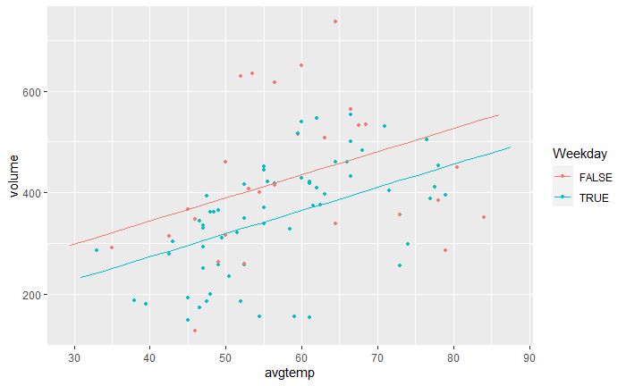

Why are there two lines?

2 conditions (2 category levels for weekday - TRUE or FALSE) If we had 7 category levels, we’d get 7 lines.

volume = intercept + (b_avg_temp * avgtemp) + (b_weekday * weekday)

when workday is FALSE

volume = intercept + (b_avg_temp * avgtemp)

```r
summary(model_avgtemp_weekday_summer)
```

```
Call:
lm(formula = volume ~ avgtemp + weekday + summer, data = railtrail_trim)

Residuals:
     Min       1Q   Median       3Q      Max
-236.165  -75.448    6.184   68.496  252.680

Coefficients:
            Estimate Std. Error t value Pr(>|t|)
(Intercept)   71.376     90.336   0.790 0.431630
avgtemp        6.387      1.639   3.898 0.000192 ***
weekdayTRUE  -66.958     25.505  -2.625 0.010244 *
summerTRUE   -59.977     41.052  -1.461 0.147662
---
Signif. codes:  0 ‘***’ 0.001 ‘**’ 0.01 ‘*’ 0.05 ‘.’ 0.1 ‘ ’ 1

Residual standard error: 111.1 on 86 degrees of freedom
Multiple R-squared:  0.2659,    Adjusted R-squared:  0.2402
F-statistic: 10.38 on 3 and 86 DF,  p-value: 6.714e-06
```

Adding summer column to the model is not justified since it is has a p-value > 0.05 (not significant), R squared has only improved by 0.0183.

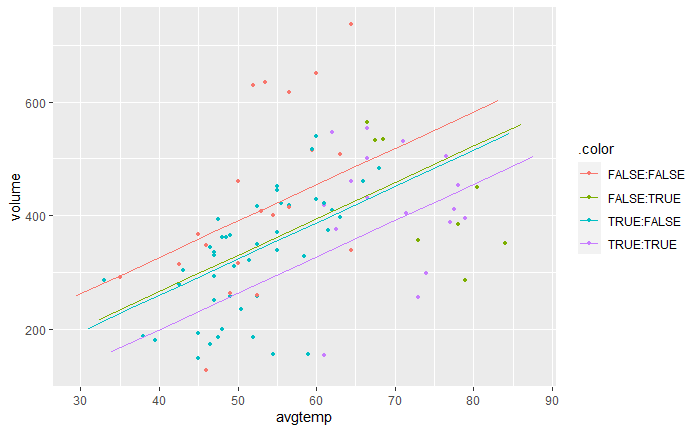

```r
plotModel(model_avgtemp_weekday_summer)
```

We are not going to include summer (at this point), based on p-value.

If we were, I’d look more into what we’re about to do. - looking at interactions (it depends)

### Interactions

Sometimes there will be a dependancy between your “independent” predictors.

Back to your second model: with avg_temp and weekday:

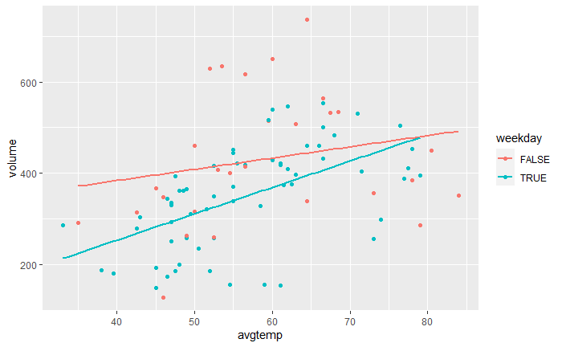

```r
railtrail_trim %>%
  ggplot(aes(x = avgtemp, y = volume, colour = weekday)) +
  geom_point() +
  geom_smooth(method = "lm", se = FALSE)
```

parallel slopes model: volume ~ avgtemp + weekday

avgtemp vs volume

the lines of best fit are different for avgtemp vs volume for the different levels weekday levels

volume ~ avgtemp + weekday + avgtemp:weekday

volume depends on avgtemp, weekday, and the dependancy of avgtemp on weekday

It depends….

what does an increase on avgtemp have on volume? It depends on whether it’s a weekday or not.

```r
summary(model_temp_wday_interTW)
```

```
Call:
lm(formula = volume ~ avgtemp + weekday + avgtemp:weekday, data = railtrail_trim)

Residuals:
     Min       1Q   Median       3Q      Max
-269.906  -78.862    2.064   68.190  291.641

Coefficients:
                    Estimate Std. Error t value Pr(>|t|)
(Intercept)          285.887    103.390   2.765  0.00696 **
avgtemp                2.457      1.718   1.431  0.15619
weekdayTRUE         -262.193    128.181  -2.045  0.04386 *
avgtemp:weekdayTRUE    3.300      2.161   1.527  0.13040
---
Signif. codes:  0 ‘***’ 0.001 ‘**’ 0.01 ‘*’ 0.05 ‘.’ 0.1 ‘ ’ 1

Residual standard error: 111 on 86 degrees of freedom
Multiple R-squared:  0.2675,    Adjusted R-squared:  0.2419
F-statistic: 10.47 on 3 and 86 DF,  p-value: 6.115e-06
```

Can read “:” as “interacting with”

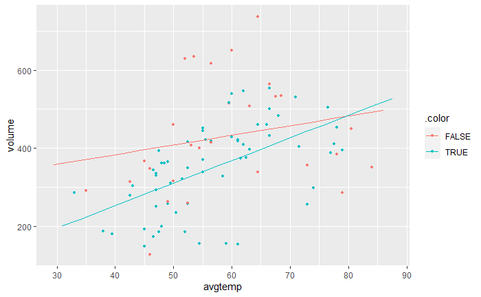

if weekday is TRUE (i.e. weekday = 1)

volume = 285 + 2.5 * avgtemp - 262 * weekday + 3.3 * avgtemp * weekday

if weekday is FALSE (i.e weekday = 0)

volume = 285 + 2.5 * avg_Temp - 262 * weekday + 3.3 * avgtemp * weekday -> volume = 285 + 2.5 * avg_Temp

(forget about our continuous and categorical interaction for the moment!)

Add cloudcover to our model

volume = b_avg * avgtemp + b_weekday * weekday + b_cloudcover * cloudcover

[figure not shown]

```r
summary(model3_terms)
```

```
Call:
lm(formula = volume ~ avgtemp + weekday + cloudcover, data = railtrail_trim)

Residuals:
     Min       1Q   Median       3Q      Max
-204.803  -58.375    6.594   60.178  277.581

Coefficients:
            Estimate Std. Error t value Pr(>|t|)
(Intercept) 200.1022    59.1826   3.381  0.00109 **
avgtemp       5.2461     0.9536   5.502 3.81e-07 ***
weekdayTRUE -47.9480    23.4061  -2.049  0.04356 *
cloudcover  -16.0115     3.3952  -4.716 9.21e-06 ***
---
Signif. codes:  0 ‘***’ 0.001 ‘**’ 0.01 ‘*’ 0.05 ‘.’ 0.1 ‘ ’ 1

Residual standard error: 100.3 on 86 degrees of freedom
Multiple R-squared:  0.4022,    Adjusted R-squared:  0.3814
F-statistic: 19.29 on 3 and 86 DF,  p-value: 1.185e-09
```

A bit more progress…

R squared shows that our model with avgtemp, weekday and cloudcover explains 40% of the variation in volume.

Our standard error has reduced to 100 users.

Interpreting our results:

For a 1 degree increase in temperature we expect 5.2 more users in volume on the trail (holding all other variables constant)

For a 40 degree, 5 cloudy weekday, we expect:

```r
200 -48+ 5.25 * 40 - 5 * 16
```

```
[1] 282
```

= 282 users

Interactions between continuous predictors

Task - 5 mins Add precip (daily precipitation in inches) into the regression model. Perform diagnostics, and if you find that precip is a significant predictor, interpret its fitted coefficient.

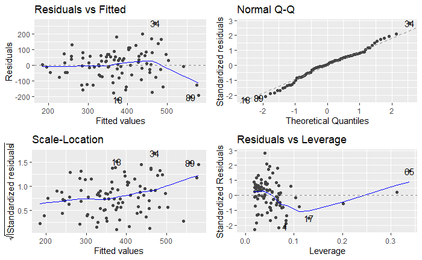

```r
autoplot(model_with_prec)
```

```r
summary(model_with_prec)
```

```
Call:
lm(formula = volume ~ avgtemp + weekday + cloudcover + precip,
    data = railtrail_trim)

Residuals:
     Min       1Q   Median       3Q      Max
-218.881  -58.924    3.428   57.285  266.250

Coefficients:
             Estimate Std. Error t value Pr(>|t|)
(Intercept)  155.0024    59.4574   2.607 0.010787 *
avgtemp        5.8743     0.9485   6.193 2.02e-08 ***
weekdayTRUE  -45.8821    22.5943  -2.031 0.045412 *
cloudcover   -12.8294     3.4783  -3.688 0.000397 ***
precip      -117.5681    43.2329  -2.719 0.007928 **
---
Signif. codes:  0 ‘***’ 0.001 ‘**’ 0.01 ‘*’ 0.05 ‘.’ 0.1 ‘ ’ 1

Residual standard error: 96.72 on 85 degrees of freedom
Multiple R-squared:  0.4501,    Adjusted R-squared:  0.4242
F-statistic: 17.39 on 4 and 85 DF,  p-value: 1.849e-10
```

Precip has significant p-value, it has a coefficient of -117 which indicates a negative relationship between precip and volume. R squared and standard error values have improved.

### Interactions between continuous predictors

Incorporate the interaction between avgtemp and precip.

volume on the railtrail is dependent on avgtemp, but that relationship might change due to whether its raining or not.

```r
model_4_terms_with_interactions <-
  lm(volume ~ avgtemp + weekday + cloudcover + precip + avgtemp:precip,
     railtrail_trim)
```

[figure not shown]

```r
summary(model_4_terms_with_interactions)
```

```
Call:
lm(formula = volume ~ avgtemp + weekday + cloudcover + precip +
    avgtemp:precip, data = railtrail_trim)

Residuals:
     Min       1Q   Median       3Q      Max
-218.775  -59.164    3.183   57.361  266.189

Coefficients:
                Estimate Std. Error t value Pr(>|t|)
(Intercept)     153.9280    63.9007   2.409 0.018189 *
avgtemp           5.8964     1.0598   5.564 3.08e-07 ***
weekdayTRUE     -45.8527    22.7365  -2.017 0.046921 *
cloudcover      -12.8866     3.6984  -3.484 0.000786 ***
precip         -100.8213   353.3547  -0.285 0.776097
avgtemp:precip   -0.2335     4.8893  -0.048 0.962023
---
Signif. codes:  0 ‘***’ 0.001 ‘**’ 0.01 ‘*’ 0.05 ‘.’ 0.1 ‘ ’ 1

Residual standard error: 97.29 on 84 degrees of freedom
Multiple R-squared:  0.4501,    Adjusted R-squared:  0.4173
F-statistic: 13.75 on 5 and 84 DF,  p-value: 8.34e-10
```

Actually, adding in this interaction has reduced the significance of some terms in our model.

```r
volume_estimates
```

```
[1] 280.0 225.5 171.0
```

Check interaction plots to see if there is an effect.

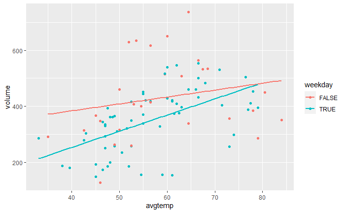

```r
ggplot(railtrail_trim, aes(avgtemp, volume, colour = weekday)) +
  geom_point() +
  geom_smooth(method = "lm", se = FALSE)
```

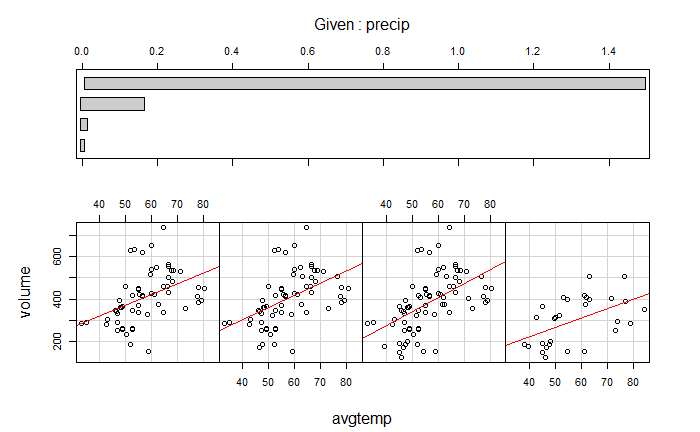

```r
coplot(volume ~ avgtemp | precip,
       data = railtrail_trim,
       rows = 1,
       panel = function(x, y, ...){
         points(x, y)
         abline(lm(y ~ x), col = "red")
       })
```

The relationship between volume and average temperature is the same for every level of precipitation. It is not likely that there is a significant interaction between avgtemp and precipitation.